# Report 1 - Data Availability

Anna Krystalli

24 December 2014

So far all mating system data, supplied by Andras and Gavin, as well as additional ecological etc data supplied by Tamas and the clutch size data published in the PLOS paper (DOI: 10.1371/journal.pbio.0060303) have been compiled onto the master data set.

Details of the datasets can be found on the data log on the project dropbox folder: https://docs.google.com/spreadsheets/d/1xIp9pmQbqIx_ZuQlTC609TI6oQLWb6vZ0NumA5oYZp4/edit?usp=sharing

The raw data can be found here: https://drive.google.com/folderview?id=0B9BMeZ9H2nRxOElvUk1mZzA1clU&usp=sharing

The up to date master spreadshet can always be found here: https://drive.google.com/file/d/0B9BMeZ9H2nRxa3VOSXF3V2tCLTg/view?usp=sharing

while descriptions of variables including details of scoring can be found here: https://drive.google.com/file/d/0B9BMeZ9H2nRxeFlHamhfalBWZjA/view?usp=sharing

So far, collation has resulted in a total of 142,461 datapoints spread over 146 variables. 45 variables are related to data quality control (confidence), references and data sources leaving a total of 101 variables for analysis of sex roles so far.

Ornament data are yet to be added as these still have significant gaps. Global distribution data have been applied for from BirdLife and these should be available soon (hopefully within the next few days although it may now be after the holidays). These will then be used to extract environmental data for each species range and determine mean and variance values for each. The Bioclim environmental data have been downloaded so we are now only awaiting the BirdLife data to continue.

A more detailed report on the distribution of values across individual variables and repeatability of values across observers will follow shortly.

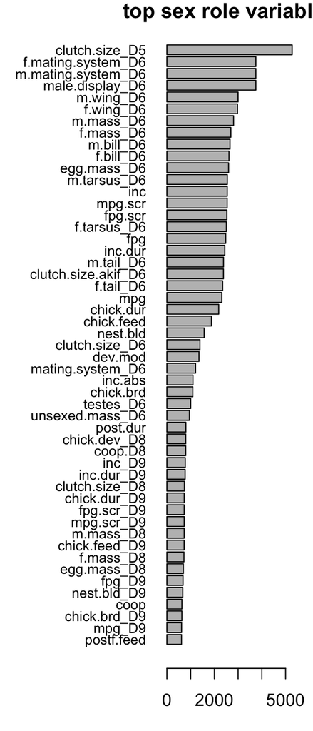

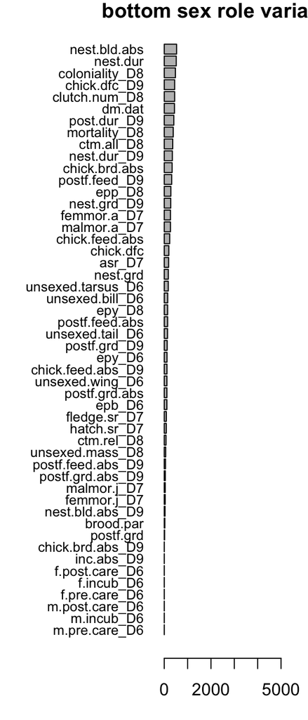

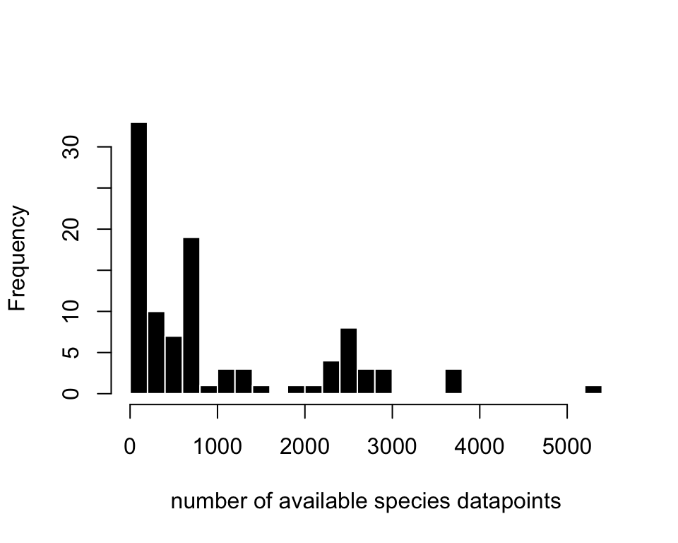

For 2586 species there is currently no sex role variable data at all, with the maximum number of variables for an individual species being 56. The following plots show the frequency distribution of data availability across variables for individual species (top) and the proportion of data availability across species as a function of the number of variables for which data is available (bottom).

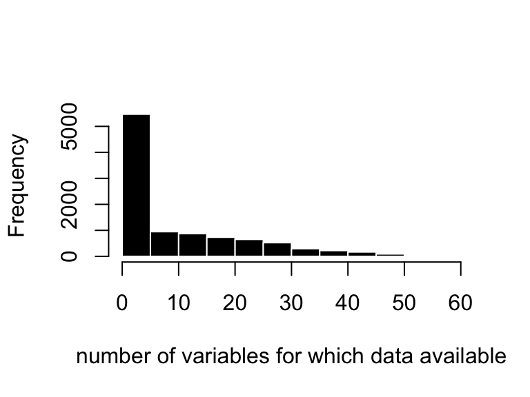

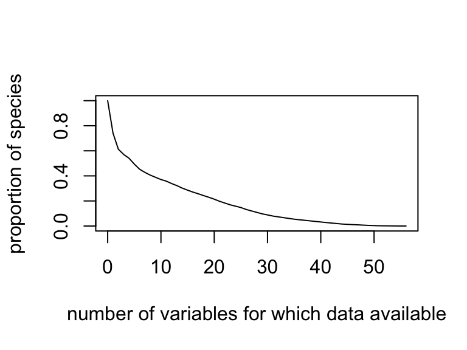

The top and bottom 20 species with respect to data availability are indicated below

```
## [1] "top 20"
```

```
##                      species variables
## 6453             Parus_major        56
## 629       Fulmarus_glacialis        56
## 9308     Agelaius_phoeniceus        55
## 8427  Dendroica_caerulescens        54
## 6460         Parus_caeruleus        54
## 1534       Calidris_maritima        54
## 9248       Fringilla_coelebs        53
## 8925       Passer_domesticus        53
## 8700         Sialia_mexicana        53
## 7962      Ficedula_hypoleuca        53
## 1468 Charadrius_alexandrinus        53
## 7229       Troglodytes_aedon        52
## 5367         Malurus_cyaneus        52
## 1507      Philomachus_pugnax        52
## 1394   Haematopus_ostralegus        52
## 9670       Melospiza_melodia        51
## 8778           Turdus_merula        51
## 6554        Delichon_urbicum        51
## 1535          Calidris_mauri        51
## 328          Lagopus_lagopus        51
## 9986   Cardinalis_cardinalis        50
```

```
## [1] "bottom 20"
```

```
##                      species variables
## 2    Rhynchotus_maculicollis         0
## 5         Nothocercus_julius         0
## 6  Nothocercus_nigrocapillus         0
## 8   Nothoprocta_curvirostris         0
## 10  Nothoprocta_taczanowskii         0
## 12        Nothura_chacoensis         0
## 14             Nothura_minor         0
## 17           Taoniscus_nanus         0
## 26   Crypturellus_berlepschi         0
## 28    Crypturellus_bartletti         0
## 29 Crypturellus_atrocapillus         0
## 30   Crypturellus_casiquiare         0
## 33       Crypturellus_duidae         0
## 35      Crypturellus_kerriae         0
## 37 Crypturellus_brevirostris         0
## 38   Crypturellus_ptaritepui         0
## 47          Eudromia_formosa         0
## 61         Talegalla_cuvieri         0
## 65          Eulipoa_wallacei         0
## 72  Megapodius_geelvinkianus         0
```

Distribution of available data across families. The first two figures show total number of datapoints across all variables available for each family. The last two image panels show a cross-tabulation of species-level variable data availability across families ie. the intensity of colour in each pixel indicates the number of species in a particular family that have data points across the number of variables indicated on the x axis. Red lines indicate the level below which families have zero data points.

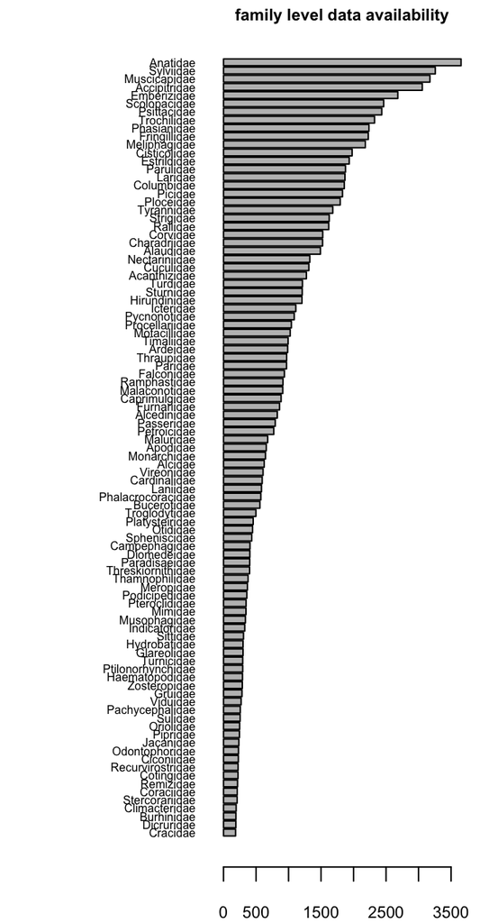

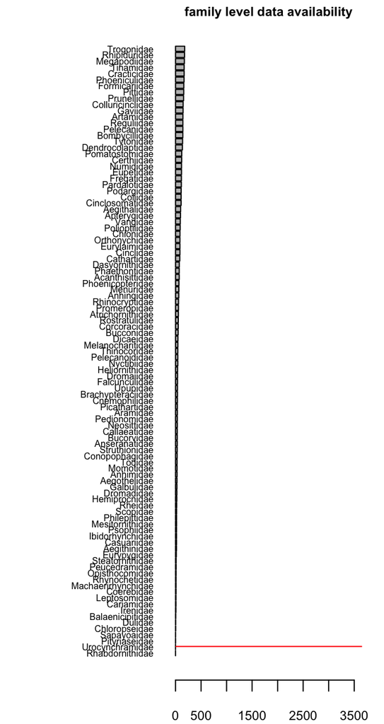

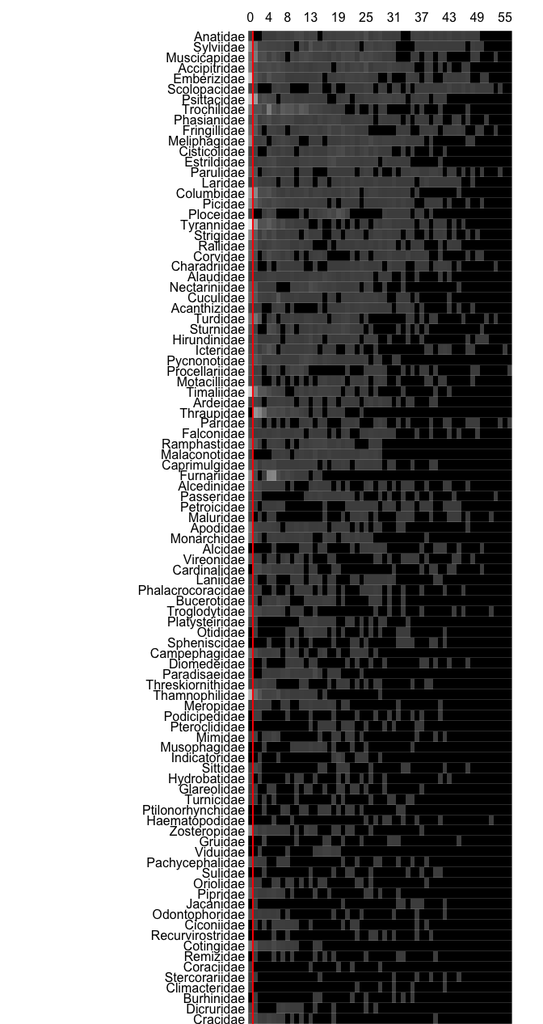

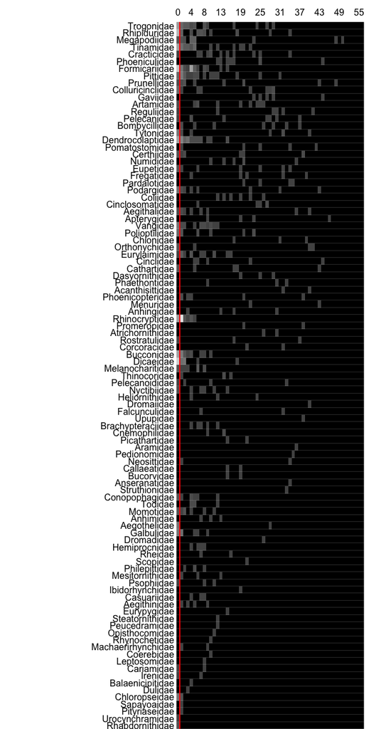

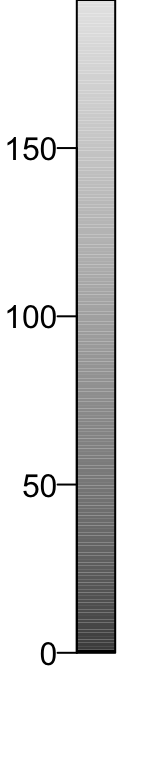